# Trabajo final - Pronóstico de casos de dengue en Colombia (2015-2025)

Series de Tiempo (3009297)

**Autores:** Daniel Bustamante Cortés, Andrés Felipe López Díaz y Viviana Astrid León Oróstegui.

**Docente:** Juan Pablo Valencia Arango.

Departamento de Estadística, Facultad de Ciencias  
Universidad Nacional de Colombia, Sede Medellín.

Noviembre 24, 2026.

```r
source("../R/00-correr_todo.R")
```

## Tema

El tema es el comportamiento de casos confirmados de dengue en Colombia. Mientras que la serie es el número de casos confirmados por dengue a nivel nacional del año 2015 al 2025, con frecuencia mensual y periodo desde enero del 2015 hasta diciembre del 2025. Por lo que el número de observaciones es 132.

En este trabajo se consideran casos confirmados los registrados en la base de microdatos de Sivigila (Instituto Nacional de Salud 2026) con clasificación de caso confirmado, sin distinguir si la confirmación fue por laboratorio o por nexo epidemiológico. En las bases de datos elegidas habían casos de dengue “posibles”, pero debido a que no se tiene certeza del diagnóstico se descartaron las observaciones con este atributo.

## Pregunta

*¿Qué tanto mejora un modelo SARIMA el pronóstico de la cantidad de casos confirmados de dengue en Colombia con frecuencia mensual a un horizonte de 6 meses, medido con MASE y RMSE, en comparación a un pronóstico de medias estacionales, referente ingenuo y a un suavizamiento exponencial, con el fin de tener una idea clara anticipada sobre el número y distribución de personal y recursos médicos por parte de la Dirección de Epidemiología y Demografía del Ministerio de Salud y Protección Social?*

Que la Dirección de Epidemiología y Demografía del Ministerio de Salud y Protección Social pueda planificar con al menos seis meses de antelación la contratación de personal, la distribución de recursos médicos y el abastecimiento de insumos para la atención del dengue es de vital importancia para planificar estrategias de prevención o asistencia a las comunidades más sensibles a este fenómeno. Si el pronóstico subestima la cantidad de casos esperados, se generan déficit de personal y medicamentos, alterando la calidad de la atención. Si por el contrario se sobreestima la demanda, se asignan recursos que no se requieren, desperdiciando dinero y mano de obra.

Si el modelo SARIMA muestra un MASE y un RMSE menores a los métodos planteados como referentes y además presenta una diferencia significativamente distinta de cero en la prueba de Diebold-Mariano corregida por horizonte, entonces se usará este modelo para mejorar las proyecciones y la asignación anticipada de recursos. Si, por el contrario, los métodos más simples resultan igual o mejor que el SARIMA, se mantendrá uno de los modelos más simples, el que menor error (RMSE y/o MASE) presente, reduciendo la complejidad, pero sin perder fiabilidad.

En caso de dar una respuesta negativa, se concluiría que la complejidad adicional agregada por el modelo SARIMA no aporta un valor significativo para la planificación de recursos médicos por parte del Ministerio de Salud y Protección Social. Se llega a esto si el RMSE y/o MASE del modelo SARIMA es mayor o igual al RMSE y/o MASE de alguno de los otros métodos de pronóstico.

En un estudio de enfermedades como el dengue se deben considerar periodos endémicos y de brote, por lo que el desempeño de los modelos SARIMA frente a los referentes se estratificará y evaluará de manera independiente: una submuestra de brote epidémico, el cual abarca epidemias de dengue nacionales y otra submuestra endémica, en los cuales se ubican los periodos habituales o de baja incidencia. Evaluar los subperiodos por separado permite verificar si la precisión del SARIMA realmente se sostiene en contingencias o si su ventaja frente al referente ingenuo se limita a periodos de menos volátiles.

## Usuario

El usuario es la Dirección de Epidemiología y Demografía del Ministerio de Salud y Protección Social, pues para tener un mejor manejo y administración del personal y recursos médicos ante el dengue, necesitan saber si un modelo SARIMA ofrece una ventaja real sobre repetir el número de casos del último mes observado, usar el promedio histórico del mismo mes en años anteriores o aplicar suavizamiento exponencial, todo esto en busca de asistir a los afectados y/o prevenir nuevos casos de la forma más eficaz posible.

## Objetivo general

Evaluar la capacidad de pronóstico de modelos SARIMA frente a los referentes propuestos medias estacionales, suavizamiento exponencial y referente ingenuo en la predicción mensual de número de casos confirmados de dengue en Colombia a un horizonte de 6 meses (del 2015 al 2025), implementando la validación de origen móvil evaluada con MASE y RMSE y la prueba de Diebold-Mariano.

## Objetivos específicos

- Caracterizar la estructura de tendencia y componentes de la serie mensual de casos confirmados de dengue y determinar el orden de integración regular y estacional mediante las pruebas ADF, PP y KPSS. Se usa como producto gráficos de descomposición de STL y tablas resumen de pruebas de raíces unitarias.
- Estimar y seleccionar el modelo SARIMA más adecuado entre los candidatos, mediante una tabla de comparación y diagnóstico de residuos, verificando estacionariedad e invertibilidad.
- Cuantificar y comparar el error de pronóstico de cada método por horizonte (1 a 6 meses) con MASE y RMSE, mediante tablas y prueba de Diebold-Mariano con corrección de horizonte.
- Evaluar la cobertura empírica de los intervalos de predicción al 95% de confianza por horizonte de pronóstico. El producto asociado es una tabla que muestra la proporción real de veces que los valores de predicción observados están dentro de los intervalos calculados.
- Realizar un análisis de sensibilidad sobre la estabilidad de los pronósticos evaluando variaciones en la ventana de entrenamiento y de como afectan los datos atípicos al modelo. Se hace mediante una tabla comparativa de métricas con diferentes especificaciones de sensibilidad.

## Revisión de literatura

La búsqueda de literatura se realizó usando Google Scholar y PubMed. Para la primera, se estructuró la siguiente cadena de búsqueda: `("dengue") AND (forecast* OR "time series" OR ARIMA OR SARIMA) AND (Colombia OR "Latin America" OR monthly)`. En PubMed se utilizó la misma sintaxis en términos MeSH y etiquetas de campo `[tiab]` para el mismo periodo. Es importante resaltar que no hay muchos artículos que apliquen modelos SARIMA como modelo principal, en la mayoria de casos se usan SARIMAX, pero como estos modelos provienen de la misma familia se consideraron óptimos para este estudio. Adicionalmente, se aplicó rastreo de citas tomando como documento semilla el estudio de Chen y Moraga (2025), a partir del cual se exploraron sus referencias (61) y se lograron ubicar estudios que con la cadena no se pudieron identificar como Gharbi et al. (2011) y Zhao et al. (2020).

Como criterios de inclusión, se seleccionaron artículos arbitrados publicados entre 2011 y 2025 que pronosticaran el número de casos de dengue utilizando series de tiempo de la familia ARIMA/SARIMA y que reportaran el horizonte de evaluación. Los criterios de exclusión aplicados fueron: estudios puramente descriptivos, artículos que solo usaran técnicas de machine learning sin utilizar los modelos de interés (ARIMA/SARIMA) y fuentes no arbitradas. Un factor clave que se consideró como factor de inclusión fue el de reporte de métricas de evaluación, todas las fuentes cuentan con este, excepto Martinez et al. (2011), el cual se dejó debido a que es de los pocos estudios que usan como enfoque central un modelo SARIMA univariado, por lo que es de alta relevancia para el estudio.

```r
tabla_comp_lit()
```

Comparación de estudios previos sobre la predicción de casos de dengue

[output not shown]

Con lo visto con la literatura se tiene que los modelos SARIMA representan adecuadamente el comportamiento del dengue a lo largo del tiempo y su ventaja se concentra en horizontes cortos (Chen y Moraga (2025) y Gharbi et al. (2011)). El aporte de las covariables en algunos casos mejora los pronósticos, sobre todo cuando hay brotes severos (Eastin et al. (2014) y Chen y Moraga (2025)), pero en otros estudios el efecto no es significativo (Navarro Valencia et al. (2021) ).

### Calibración

El RMSE depende de la escala de cada serie (semanal, anual, país, etc.) y ninguna de las fuentes tiene la misma escala que la serie de estudio, por lo que las cifras de las fuentes no sirven como umbrales directos. Lo que sí se puede extraer son comportamientos relativos, que no dependen de la escala. En primer lugar, el error crece con el horizonte, con un ARIMA sin covariables como Chen y Moraga (2025) que reportan un RMSE de 124.33 a una semana, 277.48 a cuatro y 583.04 a doce. Por otro lado, las ganancias de un modelo sobre otro suelen ser pequeñas. En Hasan et al. (2024), el SARIMA reduce el RMSE en 3.1% frente al ARIMA (5175.8 frente a 5343.2). En Navarro Valencia et al. (2021), los RMSE del SARIMA, el SARIMAX y la LSTM (25.83, 25.76 y 26.16) difieren menos de 2% entre sí. Diferencias tan pequeñas son difíciles de distinguir del ruido y las métricas pueden ordenar los modelos de manera distinta, lo que justifica evaluar con la prueba de Diebold-Mariano y reportar MASE y RMSE. También, la cobertura de los intervalos tiende a quedar por debajo del nivel nominal. Chen y Moraga (2025) reportan coberturas de entre 86.5% y 92.3% para ARIMA frente al 95%. Por ello, la cobertura empírica de los intervalos del SARIMA se interpretará frente al 95%, y valores en el rango de 86.5% a 92.3% se consideran válidos con lo visto en la literatura. En consecuencia, el modelo SARIMA se compara con los referentes propuestos y no con valores de otros estudios, es decir, con la reducción del RMSE y del MASE frente al mejor referente en el horizonte y junto a la significancia de la prueba de Diebold-Mariano.

### Brecha

Este trabajo se enfoca sobre estos vacíos. Para ello, se evalúa la capacidad predictiva de un modelo SARIMA sobre la serie mensual de casos confirmados de dengue en Colombia a un horizonte de seis meses, contrastándolo contra un referente ingenuo, medias estacionales y suavizamiento exponencial. Se consideran origen móvil, MASE y RMSE, cobertura empírica de los intervalos al 95% y prueba de Diebold-Mariano con corrección de horizonte, estratificando el análisis entre periodos de brote y endémicos.

## Marco Teórico: Pronóstico Univariado de Casos Confirmados de Dengue en Colombia mediante Modelos SARIMA

### 1. Contexto Metodológico y Criterios de Suficiencia

El presente Marco Teórico constituye el compromiso formal de fundamentación estadística del trabajo de investigación sobre la modelación y pronóstico de la incidencia mensual de dengue en Colombia para el periodo 2015–2025 ($T = 132$ observaciones). El propósito sustantivo de este desarrollo es proveer a la Dirección de Epidemiología y Demografía del Ministerio de Salud y Protección Social de herramientas cuantitativas rigurosas para anticipar con un horizonte de $h = 6$ meses la asignación de recursos médicos, contratación de personal y distribución de insumos en contingencias sanitarias.

En estricto cumplimiento de los lineamientos institucionales exigidos en el curso de Series de Tiempo, esta sección se rige por un **criterio de doble suficiencia**:

1. **Completitud:** Todo objeto estocástico, operador algebraico, transformación funcional ($\lambda$ de Box-Cox), estructura de modelo ($\text{SARIMA}$, $\text{ETS}$, $\text{Naïve}$, Medias Estacionales), parámetro y métrica de validación ($\text{RMSE}$, $\text{MASE}$, prueba de Diebold-Mariano) empleado en la solución del problema y en la fase de validación se encuentra matemáticamente definido en esta sección.
2. **Economía:** Cada elemento teórico conceptualizado en este capítulo es efectivamente operacionalizado y evaluado en las secciones posteriores del documento técnico. Se eliminan sin excepción definiciones accesorias o históricas que no tengan un uso analítico directo.

De acuerdo con las directrices metodológicas, este marco teórico evita la recitación de conceptos elementales de libros de texto y prescinde de demostraciones algebraicas extensas. En su lugar, se enuncian los teoremas y resultados fundamentales acompañados de sus **supuestos explícitos** y con su **localización bibliográfica exacta** (capítulo, sección o teorema), garantizando la máxima verificabilidad por parte del lector técnico. Todas las referencias bibliográficas seleccionadas provienen de literatura científica de **acceso público y gratuito** (Open Access, repositorios institucionales y textos abiertos).

### 2. Tabla de Notación Formal

Para garantizar la consistencia matemática a lo largo del documento, la Tabla 1 consolida el conjunto completo de símbolos, operadores, subíndices e indicadores estadísticos empleados en el trabajo.

#### Tabla 1: Notación matemática formal y su localización de introducción en el documento

| Símbolo | Significado Matemático | Sección de Introducción |
| --- | --- | --- |
| $Y_t$ | Serie temporal observada de casos confirmados mensuales de dengue en Colombia en el mes $t$ | Sección 3.1 |
| $\lambda$ | Parámetro de forma de la transformación de estabilización de varianza de Box-Cox | Sección 3.4 |
| $Y_t^{(\lambda)}$ | Serie transformada mediante la función de Box-Cox | Sección 3.4 |
| $B$ | Operador de rezago o retardo ($B^k Y_t = Y_{t-k}$) | Sección 3.3 |
| $\nabla, \nabla_s$ | Operador de diferencia regular $\nabla = (1-B)$ y estacional $\nabla_s = (1-B^s)$ | Sección 3.3 |
| $s$ | Periodo o frecuencia de estacionalidad ($s = 12$ meses para datos mensuales) | Sección 3.3 |
| $w_t$ | Serie estacionaria obtenida tras aplicar diferenciación regular $d$ y estacional $D$ | Sección 3.5 |
| $p, d, q$ | Órdenes autoregresivo, de integración y de medias móviles regulares | Sección 3.5 |
| $P, D, Q$ | Órdenes autoregresivo, de integración y de medias móviles estacionales | Sección 3.5 |
| $\phi(B), \theta(B)$ | Polinomios autoregresivo $\text{AR}(p)$ y de medias móviles $\text{MA}(q)$ regulares | Sección 3.5 |
| $\Phi(B^s), \Theta(B^s)$ | Polinomios autoregresivo $\text{SAR}(P)$ y de medias móviles $\text{SMA}(Q)$ estacionales | Sección 3.5 |
| $\epsilon_t$ | Proceso de ruido blanco gaussiano con media 0 y varianza constante $\sigma^2_\epsilon$ | Sección 3.1 |
| $\gamma(h), \rho(h)$ | Función de autocovarianza ($\text{ACVF}$) y de autocorrelación ($\text{ACF}$) en el rezago $h$ | Sección 3.2 |
| $\alpha(h)$ | Función de autocorrelación parcial ($\text{PACF}$) en el rezago $h$ | Sección 3.2 |
| $h$ | Horizonte de pronóstico en meses ($h = 1, 2, \dots, 6$) | Sección 4.2 |
| $T$ | Tamaño total de la serie observada ($T = 132$ meses, enero 2015 – diciembre 2025) | Sección 3.1 |
| $T_{train}$ | Tamaño del conjunto de entrenamiento en la ventana inicial de origen móvil | Sección 5.1 |
| $i$ | Subíndice que representa la iteración u origen en el esquema de origen móvil ($i = 1, \dots, K$) | Sección 5.1 |
| $\hat{Y}_{T+h\|T}$ | Pronóstico puntual a $h$ pasos proyectado desde el origen de tiempo $T$ | Sección 4.2 |
| $e_T(h)$ | Error de pronóstico fuera de muestra a $h$ pasos, definido como $Y_{T+h} - \hat{Y}_{T+h\|T}$ | Sección 4.2 |
| $\text{RMSE}(h)$ | Raíz del error cuadrático medio al horizonte de pronóstico $h$ | Sección 5.2 |
| $\text{MASE}(h)$ | Error absoluto medio escalado al horizonte de pronóstico $h$ | Sección 5.2 |
| $q_{naive}$ | Escalador del MASE, calculado strictly sobre la muestra de entrenamiento | Sección 5.2 |
| $I_{1-\alpha}(h)$ | Intervalo de predicción al nivel de confianza $1-\alpha$ ($80\%$ y $95\%$) para el horizonte $h$ | Sección 4.3 |
| $S_{DM}(h)$ | Estadístico de prueba de Diebold-Mariano corregido por el horizonte $h$ | Sección 5.4 |

### 3. Fundamentación de Objetos y Procesos Estocásticos

#### 3.1. Proceso Estocástico y Estacionariedad Débil

Definimos la serie mensual de casos de dengue como una realización finita $\{y_t\}_{t=1}^T$ de un proceso estocástico $\{Y_t, t \in \mathbb{Z}\}$, conceptualizado como una colección infinita de variables aleatorias ordenadas temporalmente en un espacio de probabilidad filtrado $(\Omega, \mathcal{F}, \{\mathcal{F}_t\}, \mathbb{P})$.

> **Definición 3.1 (Estacionariedad Débil o en Sentido Amplio).**
> Un proceso estocástico $\{Y_t\}$ se define como débilmente estacionario si cumple conjuntamente tres condiciones (Shumway & Stoffer, 2017, Sección 1.3): 1. La esperanza matemática es finita y constante a lo largo del tiempo: $\mathbb{E}[Y_t] = \mu < \infty, \quad \forall t \in \mathbb{Z}$. 2. La varianza es finita y no depende del tiempo: $\operatorname{Var}(Y_t) = \mathbb{E}[(Y_t - \mu)^2] = \sigma^2 < \infty, \quad \forall t \in \mathbb{Z}$. 3. La autocovarianza entre dos momentos del tiempo $t$ y $t+h$ depende exclusivamente del rezago o separación temporal $h$, y no del tiempo absoluto $t$:
> $$\operatorname{Cov}(Y_t, Y_{t+h}) = \mathbb{E}[(Y_t - \mu)(Y_{t+h} - \mu)] = \gamma(h), \quad \forall t, h \in \mathbb{Z}$$

*Supuestos explícitos:* Se asume que el proceso posee momentos de segundo orden finitos ($\mathbb{E}[Y_t^2] < \infty$). La presencia de tendencias estacionales y epidemiológicas en el dengue invalida la estacionariedad débil directa en niveles, lo que justifica la aplicación de transformaciones funcionales y operadores de diferencia.

#### 3.2. Funciones de Autocovarianza y Autocorrelación (ACVF, ACF, PACF)

La dependencia estocástica temporal del proceso se caracteriza formalmente mediante la estructura de autocovarianza y autocorrelación.

> **Definición 3.2 (ACVF y ACF).**
> La Función de Autocovarianza ($\text{ACVF}$) $\gamma(h)$ y la Función de Autocorrelación ($\text{ACF}$) $\rho(h)$ para un proceso débilmente estacionario en el rezago $h \in \mathbb{Z}$ se expresan como (Shumway & Stoffer, 2017, Sección 1.4):
> $$\gamma(h) = \operatorname{Cov}(Y_t, Y_{t+h}), \quad \rho(h) = \frac{\gamma(h)}{\gamma(0)} = \frac{\operatorname{Cov}(Y_t, Y_{t+h})}{\operatorname{Var}(Y_t)}$$
> con propiedades estructurales $\rho(0) = 1$, $|\rho(h)| \le 1$ y simetría $\rho(h) = \rho(-h)$.

> **Definición 3.3 (PACF).**
> La Función de Autocorrelación Parcial ($\text{PACF}$) $\alpha(h)$ mide la correlación lineal entre $Y_t$ y $Y_{t+h}$ tras eliminar la influencia lineal de las variables intermedias $\{Y_{t+1}, Y_{t+2}, \dots, Y_{t+h-1}\}$. Formalmente se define como el coeficiente $\phi_{hh}$ en la regresión autoregresiva de orden $h$ (Shumway & Stoffer, 2017, Sección 3.2):
> $$\alpha(h) = \phi_{hh}, \quad \text{donde } Y_t = \sum_{j=1}^h \phi_{hj} Y_{t-j} + e_t$$

*Uso metodológico en la solución:* La ACF y la PACF estimadas sobre la serie estacionaria permiten identificar preliminarmente los órdenes de los polinomios autoregresivos y de medias móviles ($p, q, P, Q$) en la fase de identificación de Box-Jenkins.

#### 3.3. Operadores de Rezago y Diferenciación

La manipulación algebraica de componentes temporales se efectúa mediante la álgebra de operadores sobre espacios de secuencias.

> **Definición 3.4 (Operador de Rezago y Diferencia).**
> El operador de rezago $B$ desplaza la serie un periodo hacia atrás: $B^k Y_t = Y_{t-k}$ para $k \in \mathbb{N}_0$. Se definen los operadores de diferencia regular $\nabla$ y estacional $\nabla_s$ de periodo $s = 12$ como (Hyndman & Khandakar, 2008, Sección 3; Hyndman & Athanasopoulos, 2021, Capítulo 9.1):
> $$\nabla Y_t = (1 - B) Y_t = Y_t - Y_{t-1}$$
> $$\nabla_s^D \nabla^d Y_t = (1 - B^s)^D (1 - B)^d Y_t$$

#### 3.4. Transformación de Estabilización de Varianza de Box-Cox

Las series epidemiológicas presentan frecuentemente heterocedasticidad condicionada por el nivel de la serie (mayor varianza en periodos epidémicos de alta incidencia). Para estabilizar la varianza del error y aproximar la normalidad, se aplica la familia de transformaciones paramétricas de Box-Cox.

> **Definición 3.5 (Transformación de Box-Cox).**
> Dada la serie de casos observados $Y_t > 0$, la transformación funcional $Y_t^{(\lambda)}$ está parametrizada por $\lambda \in \mathbb{R}$ según (Vélez et al., 2015; Hyndman & Athanasopoulos, 2021, Capítulo 3.1):
> $$Y_t^{(\lambda)} = \begin{cases} \frac{Y_t^\lambda - 1}{\lambda}, & \text{si } \lambda \neq 0 \\ \ln(Y_t), & \text{si } \lambda = 0 \end{cases}$$

*Supuesto explícito y restricción metodológica:* La estimación del parámetro óptimo $\lambda$ (por ejemplo, vía máxima verosimilitud de Guerrero) se realiza **estrictamente sobre la muestra de entrenamiento** $T_{train}$ para prevenir la contaminación por información del futuro (data leakage) en la fase de pronóstico.

#### 3.5. Estructura Formal del Modelo SARIMA

El modelo primario objeto de evaluación en este trabajo es el proceso Autoregresivo Integrado de Medias Móviles Estacional ($\text{SARIMA}$), formulado por Box y Jenkins para capturar dinámicas estocásticas con patrones periódicos.

> **Definición 3.6 (Modelo** $\text{SARIMA}(p,d,q)\times(P,D,Q)_s$).
> Sea $Y_t$ la serie observada y $Y_t^{(\lambda)}$ su transformación de Box-Cox. Decimos que $\{Y_t^{(\lambda)}\}$ sigue un modelo $\text{SARIMA}(p,d,q)\times(P,D,Q)_s$ con periodo estacional $s = 12$ si la serie diferenciada $w_t = (1-B)^d (1-B^s)^D Y_t^{(\lambda)}$ satisface la ecuación polinomial (Hyndman & Khandakar, 2008, Sección 3.1; Hyndman & Athanasopoulos, 2021, Capítulo 9.9):
> $$\phi_p(B) \Phi_P(B^s) (1-B)^d (1-B^s)^D Y_t^{(\lambda)} = \theta_q(B) \Theta_Q(B^s) \epsilon_t$$
> donde los operadores polinomiales se definen como: 1. Polinomio autoregresivo regular: $\phi_p(B) = 1 - \phi_1 B - \phi_2 B^2 - \dots - \phi_p B^p$ 2. Polinomio autoregresivo estacional: $\Phi_P(B^s) = 1 - \Phi_1 B^s - \Phi_2 B^{2s} - \dots - \Phi_P B^{Ps}$ 3. Polinomio de medias móviles regular: $\theta_q(B) = 1 + \theta_1 B + \theta_2 B^2 + \dots + \theta_q B^q$ 4. Polinomio de medias móviles estacional: $\Theta_Q(B^s) = 1 + \Theta_1 B^s + \Theta_2 B^{2s} + \dots + \Theta_Q B^{Qs}$ y $\{\epsilon_t\} \sim \text{iid } \mathcal{N}(0, \sigma^2_\epsilon)$ representa un proceso de ruido blanco gaussiano.

#### 3.6. Modelos de Referencia (Benchmarks)

Para determinar si la complejidad matemática del modelo SARIMA se traduce en una ventaja predictiva real para el usuario institucional, se contrastará frente a tres referentes de diferente nivel de sofisticación (Hyndman & Athanasopoulos, 2021, Capítulos 5.2 y 8.1):

1. **Referente Ingenuo (Naïve Benchmark):** Proyecta como pronóstico puntual para cualquier horizonte $h$ el último valor observado en el origen de predicción:
   $$\hat{Y}_{T+h|T}^{\text{Naïve}} = Y_T, \quad \forall h \ge 1$$
2. **Medias Estacionales / Naïve Estacional (Seasonal Naïve Benchmark):** Proyecta el valor observado en el mismo mes del periodo anual anterior ($s = 12$):
   $$\hat{Y}_{T+h|T}^{\text{SNaïve}} = Y_{T+h - m s}, \quad \text{donde } m = \lfloor(h-1)/s\rfloor + 1$$
3. **Suavizamiento Exponencial Holt-Winters / ETS (Error, Trend, Seasonal):** Modelo de espacio de estados que descompone la serie en componentes de nivel ($l_t$), tendencia ($b_t$) y estacionalidad ($s_t$). Para una estructura aditiva $\text{ETS}(A,A,A)$, la ecuación de pronóstico a $h$ pasos es:
   $$\hat{Y}_{T+h|T}^{\text{ETS}} = l_T + h b_T + s_{T+h - m s}$$

### 4. Resultados Teóricos, Teoremas y Pronóstico Óptimo

#### 4.1. Condiciones de Causalidad e Invertibilidad

La validez matemática del modelo SARIMA para la generación de pronósticos estables requiere garantizar que el proceso admita una representación autoregresiva de orden infinito $\text{AR}(\infty)$ y de medias móviles de orden infinito $\text{MA}(\infty)$.

> **Teorema 4.1 (Condición de Causalidad).**
> El proceso $\text{SARIMA}(p,d,q)\times(P,D,Q)_s$ proyectado sobre la serie diferenciada $w_t$ es **causal** (depende únicamente del pasado del ruido blanco $\{\epsilon_s, s \le t\}$) si y solo si los ceros de los polinomios autoregresivos regular $\phi_p(z)$ y estacional $\Phi_P(z^s)$ se encuentran estrictamente fuera del círculo unitario en el plano complejo (Shumway & Stoffer, 2017, Teorema 3.1):
> $$\phi_p(z) \neq 0 \quad \text{y} \quad \Phi_P(z^s) \neq 0 \quad \forall z \in \mathbb{C} \text{ tal que } |z| \le 1$$
> Bajo esta condición, existe una representación $\text{MA}(\infty)$ dada por $w_t = \sum_{j=0}^{\infty} \psi_j \epsilon_{t-j}$, donde $\sum_{j=0}^{\infty} |\psi_j| < \infty$.

> **Teorema 4.2 (Condición de Invertibilidad).**
> El proceso es **invertible** (el ruido blanco $\epsilon_t$ puede expresarse como combinación lineal convergente del pasado del proceso $\{w_s, s \le t\}$) si y solo si los ceros de los polinomios de medias móviles regular $\theta_q(z)$ y estacional $\Theta_Q(z^s)$ se encuentran estrictamente fuera del círculo unitario en el plano complejo (Shumway & Stoffer, 2017, Teorema 3.2):
> $$\theta_q(z) \neq 0 \quad \text{y} \quad \Theta_Q(z^s) \neq 0 \quad \forall z \in \mathbb{C} \text{ tal que } |z| \le 1$$
> Bajo esta condición, existe una representación $\text{AR}(\infty)$ dada por $\epsilon_t = \sum_{j=0}^{\infty} \pi_j w_{t-j}$, donde $\sum_{j=0}^{\infty} |\pi_j| < \infty$.

*Supuestos explícitos:* Los polinomios $\phi_p(z)$ y $\theta_q(z)$ no comparten raíces comunes (ausencia de cancelación de factores).

#### 4.2. Formulación del Predictor Óptimo Lineal y Varianza del Error

> **Teorema 4.3 (Predictor Óptimo de Mínimo Error Cuadrático Medio).**
> Sea el conjunto de información disponible hasta el momento $T$ denotado por la $\sigma$-álgebra $\mathcal{F}_T = \sigma(Y_1, Y_2, \dots, Y_T)$. El predictor puntual $\hat{Y}_{T+h|T}$ que minimiza el error cuadrático medio de predicción $\mathbb{E}[(Y_{T+h} - g(\mathcal{F}_T))^2]$ es la esperanza condicional (Shumway & Stoffer, 2017, Sección 3.4 y Teorema 3.3):
> $$\hat{Y}_{T+h|T} = \mathbb{E}[Y_{T+h} \mid \mathcal{F}_T]$$
> Expresando el proceso en su representación de medias móviles $Y_{T+h} = \sum_{j=0}^{\infty} \psi_j \epsilon_{T+h-j}$ con $\psi_0 = 1$, el error de pronóstico a $h$ pasos $e_T(h)$ es:
> $$e_T(h) = Y_{T+h} - \hat{Y}_{T+h|T} = \sum_{j=0}^{h-1} \psi_j \epsilon_{T+h-j}$$
> La media del error de pronóstico es nula ($\mathbb{E}[e_T(h)] = 0$) y su varianza teórica a $h$ pasos está dada por (Shumway & Stoffer, 2017, Sección 3.4):
> $$\sigma^2(h) = \operatorname{Var}(e_T(h)) = \sigma^2_\epsilon \sum_{j=0}^{h-1} \psi_j^2$$

*Propiedad fundamental:* La varianza del error de pronóstico $\sigma^2(h)$ es una función no decreciente del horizonte $h$.

#### 4.3. Intervalos de Predicción e Incertidumbre

> **Definición 4.1 (Intervalos de Predicción Gaussianos).**
> Bajo el supuesto de que el proceso de ruido blanco es independiente e idénticamente distribuido normal $\{\epsilon_t\} \sim \text{iid } \mathcal{N}(0, \sigma^2_\epsilon)$, el error de pronóstico $e_T(h)$ sigue una distribución gaussiana. El intervalo de predicción simétrico de nivel $(1-\alpha) \times 100\%$ para $Y_{T+h}$ se construye como (Hyndman & Athanasopoulos, 2021, Capítulo 5.5):
> $$I_{1-\alpha}(h) = \left[ \hat{Y}_{T+h|T} - z_{1-\alpha/2} \sqrt{\sigma^2(h)}, \quad \hat{Y}_{T+h|T} + z_{1-\alpha/2} \sqrt{\sigma^2(h)} \right]$$
> donde $z_{1-\alpha/2}$ representa el cuantil $(1-\alpha/2)$ de la distribución normal estándar $\mathcal{N}(0,1)$.

*Limitación teórica:* En la práctica, este intervalo gaussiano ignora la incertidumbre en la estimación de los parámetros del modelo y supone colas normales. Por ello, se contrasta empíricamente con intervalos construidos mediante **bootstrap de residuos** (Hyndman & Athanasopoulos, 2021, Capítulo 5.5).

### 5. Herramientas Metodológicas de Evaluación y Validación Fuera de Muestra

#### 5.1. Esquema de Validación por Origen Móvil (Rolling-Origin Cross-Validation)

Para evaluar la capacidad predictiva de los modelos en condiciones operativas reales y evitar el sobreajuste en muestra, se implementa una estructura de **validación por origen móvil** (tiempo de evaluación fuera de muestra con ventana creciente) (Hyndman & Athanasopoulos, 2021, Capítulo 5.8).

Sea $T_{train}$ la longitud de la ventana inicial de entrenamiento. En cada iteración $i = 1, 2, \dots, K$ (donde $K$ es el número total de cortes o resubmuestras de validación, con $K \ge 25$ según los requerimientos del curso): 1. El modelo se reestima utilizando únicamente los datos observados hasta el origen $T_i = T_{train} + i - 1$. 2. Se generan pronósticos puntuales e intervalos a los horizontes $h = 1, 2, \dots, 6$ meses: $\hat{Y}_{T_i+h | T_i}$. 3. Se registra la serie de errores fuera de muestra: $e_{T_i}(h) = Y_{T_i+h} - \hat{Y}_{T_i+h | T_i}$.

#### 5.2. Métricas Fuera de Muestra: RMSE y MASE

Las métricas de precisión fuera de muestra sintetizan la magnitud de los errores observados a través de los $K$ orígenes móviles para cada horizonte $h$.

> **Definición 5.1 (Raíz del Error Cuadrático Medio - RMSE).**
> Para un horizonte fijo $h$, el $\text{RMSE}(h)$ penaliza de forma cuadrática las grandes desviaciones (Hyndman & Koehler, 2006, Sección 3.1):
> $$\text{RMSE}(h) = \sqrt{ \frac{1}{K} \sum_{i=1}^K \left( e_{T_i}(h) \right)^2 }$$

> **Definición 5.2 (Error Absoluto Medio Escalado - MASE).**
> El $\text{MASE}(h)$ es una métrica de precisión invariante a la escala de la variable, propuesta por Hyndman y Koehler (2006), que compara el error absoluto medio del modelo candidato contra el error absoluto medio en muestra de un pronóstico ingenuo estacional ($s = 12$):
> $$\text{MASE}(h) = \frac{\frac{1}{K} \sum_{i=1}^K |e_{T_i}(h)|}{q_{naive}}$$
> donde el escalador $q_{naive}$ se define explícita y formalmente como (Hyndman & Koehler, 2006, Sección 3.2):
> $$q_{naive} = \frac{1}{T_{train} - s} \sum_{t=s+1}^{T_{train}} |Y_t - Y_{t-s}|$$

*Regla conceptual fundamental:* **El escalador** $q_{naive}$ debe calcularse de manera estricta y exclusiva sobre los datos de la muestra de entrenamiento inicial $T_{train}$. Calcular el escalador sobre la serie completa $T$ constituiría una violación metodológica grave al incorporar información futura en la escala de medición. Un $\text{MASE}(h) < 1$ indica que el modelo evaluado supera al referente ingenuo estacional fuera de muestra en el horizonte $h$.

#### 5.3. Cobertura Empírica de Intervalos de Predicción

Para corroborar si la incertidumbre declarada por los modelos es numéricamente fidedigna, se evalúa la cobertura empírica de los intervalos de predicción construidos al $80\%$ y $95\%$ nominales.

> **Definición 5.3 (Cobertura Empírica).**
> La cobertura empírica $\hat{C}_{1-\alpha}(h)$ para un horizonte $h$ y un nivel de confianza nominal $(1-\alpha)$ es la proporción real de observaciones fuera de muestra que caen dentro de los límites del intervalo proyectado (Hyndman & Athanasopoulos, 2021, Capítulo 5.5):
> $$\hat{C}_{1-\alpha}(h) = \frac{1}{K} \sum_{i=1}^K \mathbb{I}\left( Y_{T_i+h} \in I_{1-\alpha, T_i}(h) \right)$$
> donde $\mathbb{I}(\cdot)$ es la función indicadora.

*Criterio de interpretación:* Con $K \approx 25$ orígenes, existe un error de muestreo apreciable ($\approx \pm 0.09$ para una proporción nominal de $0.95$). Por tanto, desviaciones pequeñas (e.g., cobertura empírica del $91\%$ frente a un nominal del $95\%$) están dentro del rango aleatorio esperable, mientras que diferencias pronunciadas (e.g., cobertura del $65\%$) evidencian fallas en el supuesto de normalidad o subestimación de la variabilidad.

#### 5.4. Prueba de Comparación de Precisión de Diebold y Mariano

Para establecer si la superioridad observada en las métricas puntuales (MASE o RMSE) entre el modelo SARIMA y los referentes es estadísticamente significativa o si puede ser atribuida al ruido muestral, se aplica la prueba formal de Diebold y Mariano (1995).

> **Definición 5.4 (Estadístico de Diebold-Mariano).**
> Sean $\{e_{1, i}(h)\}_{i=1}^K$ y $\{e_{2, i}(h)\}_{i=1}^K$ las secuencias de errores de pronóstico a $h$ pasos de dos modelos competidores (e.g., SARIMA vs. Naïve Estacional) obtenidos en los $K$ orígenes de validación. Se define la serie de diferencias de pérdida $d_i(h)$ mediante una función de pérdida $L(\cdot)$ (típicamente cuadrática $L(e) = e^2$ o absoluta $L(e) = |e|$):
> $$d_i(h) = L(e_{1, i}(h)) - L(e_{2, i}(h))$$
> Se plantea el contraste de hipótesis formal (Diebold & Mariano, 1995, Sección 1.1):
> $$H_0: \mathbb{E}[d_i(h)] = 0 \quad \text{(Igualdad de precisión predictiva esperada)}$$
> $$H_1: \mathbb{E}[d_i(h)] < 0 \quad \text{(El Modelo 1 es significativamente más preciso que el Modelo 2)}$$
> El estadístico de prueba $S_{DM}(h)$ se define como (Diebold & Mariano, 1995, Sección 1.2):
> $$S_{DM}(h) = \frac{\bar{d}(h)}{\sqrt{ \frac{\hat{V}(h)}{K} }} \ \xrightarrow{d} \ \mathcal{N}(0, 1) \quad \text{bajo } H_0$$
> donde $\bar{d}(h) = \frac{1}{K} \sum_{i=1}^K d_i(h)$ y $\hat{V}(h)$ es un estimador consistente de la varianza asintótica de la media de las diferencias de pérdida, que incorpora la autocovarianza hasta el rezago $(h-1)$ para corregir la autocorrelación inducida por horizontes de pronóstico solapados ($h > 1$):
> $$\hat{V}(h) = \hat{\gamma}_d(0) + 2 \sum_{k=1}^{h-1} \hat{\gamma}_d(k)$$
> con $\hat{\gamma}_d(k) = \frac{1}{K} \sum_{i=k+1}^K (d_i(h) - \bar{d}(h))(d_{i-k}(h) - \bar{d}(h))$.

*Advertencia de supuestos y potencia:* La prueba de Diebold-Mariano asume que los modelos comparados no están anidados (condición satisfecha al comparar SARIMA contra Naïve Estacional o ETS). Con un número de orígenes $K \approx 25$, la potencia del contraste es moderada, por lo que un no rechazo de $H_0$ debe interpretarse rigurosamente como la imposibilidad empírica de distinguir el desempeño predictivo frente al ruido muestral, y no como una prueba concluyente de equivalencia teórica.

## Solución al problema

### ¿Qúe dice la serie visualmente?

En primer lugar, se procede a graficar la serie, su ACF y PACF, con el fin de identificar patrones o comportamientos. Se cargan los datos y se convierten en tipo `ts`, que es el formato soportado por las funciones hechas.

```r
ruta_datos <- here("datos", "procesados", "serie_dengue_2015_2025.csv")
datos <- read.csv(ruta_datos)
serie <- ts(datos$casos_confirmados, start = c(2015, 1),
            frequency = 12)
```

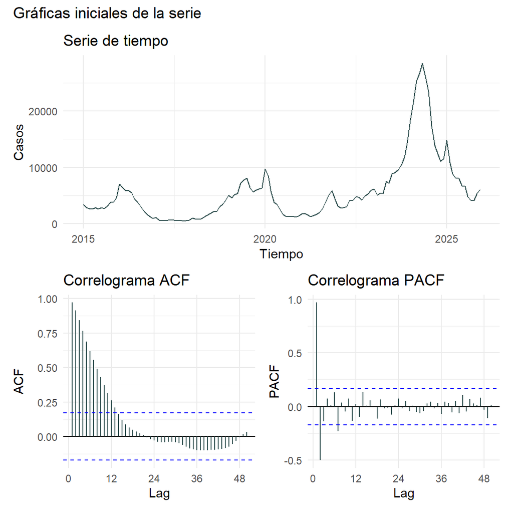

```r
graficas(serie = serie, titulo = "Gráficas iniciales de la serie")
```

A partir del gráfico de la serie se nota un comportamiento repetitivo de crecer y decrecer desde 2015 hasta 2023, donde los casos fluctuan entre 500 a 10000 casos. Luego, en el 2024 se nota un pico que representa un aumento en el número de casos considerablemente, lo cual es un indicio de tendencia. Esto se se refuerza con la ACF que decae lentamente.

La PACF tiene en el primer rezago un valor muy cercano a 1, por lo que el valor de un mes está muy condicionado por el nivel del mes anterior.

En el ACF y PACF no hay picos aislados en los rezagos múltiplos de 12. Por lo que, de forma descriptiva, no parece haber una estacionalidad anual fuerte evidente en los datos crudos.

### Transformación

En primer lugar, es necesario verificar si es necesario aplicar algún tipo de transformación a la varianza.

```r
transformacion <- bc_trans(z = serie)
```

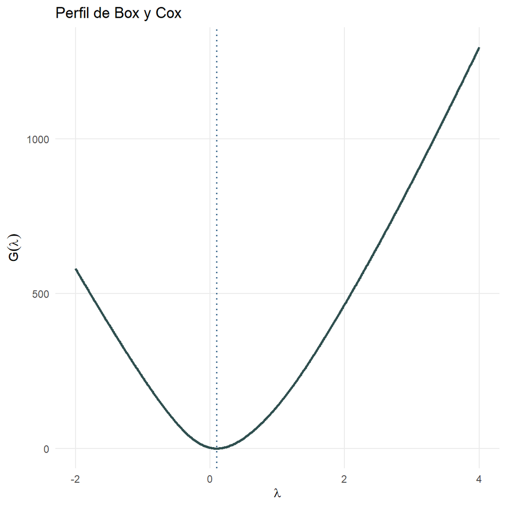

```r
transformacion$grafico
```

La estimación de $\lambda$ y su respectivo intervalo de confianza son respectivamente:

```r
transformacion$lambda
```

```
[1] 0.1
```

```r
transformacion$G0
```

```
[1] 2.374234
```

```r
transformacion$ic
```

```
       inf        sup
-0.0266454  0.2291476
```

Con $\hat{\lambda}=0.1$ y un intervalo de confianza al 95% de $(-0.03, 0.23)$, se tiene que el $0$ está incluido, por lo que es necesario aplicar una transformación y la más adecuada según Box-Cox es una logaritmica. Esta idea se refuerza con $G_0$, el cual presento un valor de $2.37 \leq \chi^2_{0.95,1}= 3.841$, por lo que no se rechaza la hipótesis nula $H_0:\lambda=0$ frente a $H_1:\lambda \ne 0$, y se concluye de igual forma acerca de la transformación logaritmica.

Se aplica logaritmo a la serie:

```r
serie <- log(serie)
```

### Diferenciación

Para determinar el número de diferencias ordinarias y estacionales ($d$ y $D$), se dibujan las 4 ACFs de $\log(Z_t)$, $\nabla\log(Z_t)$ $\nabla_s\log(Z_t)$ y $\nabla\nabla_s\log{Z_t}$, donde $Z_t$ representa la serie original:

```r
diferenciaciones <- bc_dif(z = serie)
```

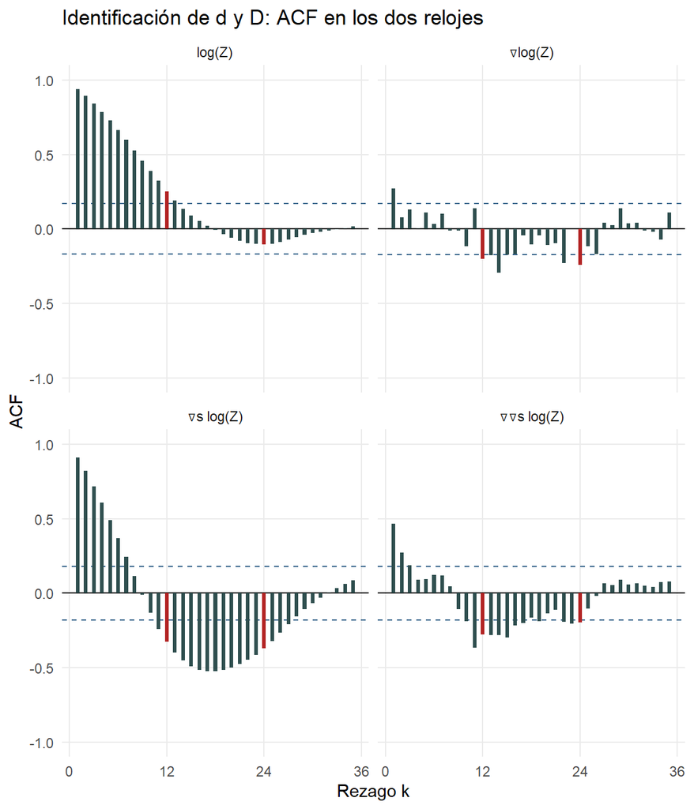

```r
diferenciaciones$grafico
```

En la serie original ($Z$) se muestra un decaimiento lento desde $r_1 \approx 0,94$ a lo largo de los primeros rezagos, señal clara de no estacionariedad en el reloj regular ($d \ge 1$). Luego de aplicar una diferencia ordinaria ($\nabla Z$) la ACF cae inmediatamente y se corta en los primeros rezagos (solo sobresale ligeramente $r_1 \approx 0,28$). En el reloj estacional (barras rojas en $12, 24, 36$), no hay decaimiento lento ni persistencia: $r_{12} \approx -0,20$ y $r_{24} \approx -0,24$ rozan apenas la banda de significancia y $r_{36} \approx 0$. No hay evidencia de raíz unitaria estacional que exija $D = 1$. Con solo la diferencia estacional ($\nabla_s Z$) sigue habiendo un decaimiento lento desde $r_1 \approx 0,90$, confirmando que falta la diferencia regular $d = 1$. Por último, con la diferencia ordinaria y estacional **(**$\nabla\nabla_s Z$) se ve una autocorrelación negativa alrededor del rezago $12$ ($r_{11} \approx -0,37$, $r_{12} \approx -0,28$ y varios rezagos negativos entre $10$ y $24$) y mantiene decaimiento en $1, 2, 3$. Esto es típico de aplicar una diferencia estacional $\nabla_{12}$ de más cuando el componente estacional es estacionario o determinístico.

En conclusión, es suficiente con una diferencia ordinaria **(**$d = 1, D = 0$):

```r
serie <- diff(serie, differences = 1)
```

Si se usan las funciones `nsdiffs` y `ndiffs` se obtienen las mismas conclusiones:

```r
diferenciaciones$d_sugerido
```

```
[1] 1
```

```r
diferenciaciones$D_sugerido
```

```
[1] 0
```

### Órdenes

Primero se mira la ACF (con banda de Bartlett) y PACF de la serie ya transformada y diferenciada para detectar posibles candidatos:

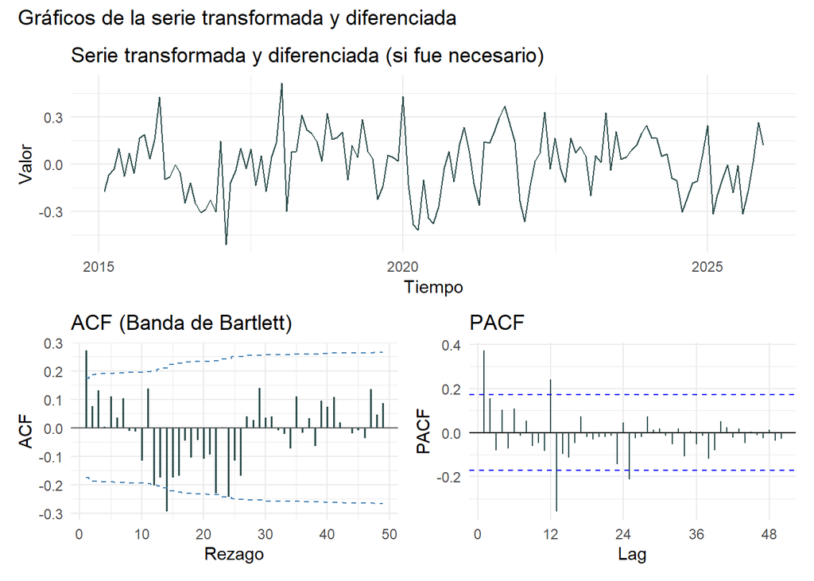

```r
graficas_dif(serie = serie, titulo = "Gráficos de la serie transformada y diferenciada")
```

La PACF se corta en el primer rezago, esto sumado al decaimiento sinusoidal de la ACF, propone un AR(1) $(1,1,0)$. Como tanto la ACF y la PACF se cortan en el primer rezago se proponen los siguientes candidatos parsimoniosos en la parte regultar: $(1,1,1)$ y $(0,1,1)$, sumados al anterior dicho.

En cuanto a la parte estacional, en la ACF se nota que el rezago 12 es significativo, en los demás rezagos múltiplos de 12 pasa lo contrario, por lo que es posible proponer $(0,0,1)_{\nabla_{12}}$. De forma similar pasa en la PACF, por lo que otra propuesta es $(1,0,0)_{\nabla_{12}}$. Tanto en la ACF como en la PACF se nota un decaimiento a partir del rezago 12, por lo que otro candidato es $(1,0,1)_{\nabla_{12}}$. Se resalta que la señal de estacionalidad se ve principalmente en la PACF.

De esta manera los candidatos son:

- $\text{SARIMA}(0,1,1)(0,0,1)_{12}$.
- $\text{SARIMA}(0,1,1)(1,0,0)_{12}$.
- $\text{SARIMA}(0,1,1)(1,0,1)_{12}$.
- $\text{SARIMA}(1,1,0)(0,0,1)_{12}$.
- $\text{SARIMA}(1,1,0)(1,0,0)_{12}$.
- $\text{SARIMA}(1,1,0)(1,0,1)_{12}$.
- $\text{SARIMA}(1,1,1)(0,0,1)_{12}$.
- $\text{SARIMA}(1,1,1)(1,0,0)_{12}$.
- $\text{SARIMA}(1,1,1)(1,0,1)_{12}$.

### Constante

```r
constante(serie)
```

```
$w_barra
[1] 0.004426814

$factor_suma
[1] 2.054498

$S_W
[1] 0.0246025

$t_muestral
[1] 0.1799335

$intercepto
[1] 0.003901824

$ee_interc
[1] 0.05315707

$t_modelo
[1] 0.07340179

$incluir_c
[1] FALSE
```

La media muestral de la serie diferenciada es $\overline{W} = 0.0044$. Dado que el factor de ajuste por autocorrelación hasta el rezago $h = s + 1 = 13$ dió positivo ($1 + 2\sum_{k=1}^{13} r_k = 2.0545$), se pudo calcular el error estándar de la media muestral, obteniendo $S_W = 0,0246$. El estadístico resultante es $t_{\text{muestral}} = \overline{W} / S_W = 0,180$, valor que es menor a $2$.

Al ajustar el modelo preliminar sobre $W_t$ incluyendo el intercepto por máxima verosimilitud, se obtuvo una estimación $\hat{\theta}_0 = 0,0039$ con un error estándar de $0.0532$, lo que arroja un estadístico $t = 0.073$, que también es menor a $2$.

Ambas pruebas coinciden en que la media de $W_t$ no difiere estadísticamente de cero. En consecuencia, no se incluye la constante$\theta_0$ (`include.mean = FALSE`) y se continúa con el ajuste de los modelos candidatos sin término de deriva.

### Comparación entre candidatos

Como ya se vió en el paso anterior, para esta serie de tiempo no se debe incluir la constante o intercepto. Esta decisión se trae hasta los criterios de información en `incluir_constante = FALSE`.

```r
candidatos <- list(c(0,1,0,1), c(0,1,1,0), c(0,1,1,1), c(1,0,0,1), c(1,0,1,0),
                   c(1,0,1,1), c(1,1,0,1), c(1,1,1,0), c(1,1,1,1))
comparar_candidatos(w = serie, candidatos = candidatos, incluir_constante = FALSE)
```

Criterios de información

| Modelo | M | AIC | BIC | SBC |
| --- | --- | --- | --- | --- |
| $\text{SARIMA}(1,1,0)(1,0,1)_{12}$ | 3 | -435.33 | -428.49 | -427.01 |
| $\text{SARIMA}(1,1,1)(1,0,1)_{12}$ | 4 | -433.75 | -425.78 | -422.67 |
| $\text{SARIMA}(1,1,0)(1,0,0)_{12}$ | 2 | -416.34 | -411.99 | -410.80 |
| $\text{SARIMA}(0,1,1)(1,0,1)_{12}$ | 3 | -418.14 | -412.53 | -409.83 |
| $\text{SARIMA}(1,1,1)(1,0,0)_{12}$ | 3 | -415.69 | -410.28 | -407.38 |
| $\text{SARIMA}(1,1,0)(0,0,1)_{12}$ | 2 | -407.81 | -404.01 | -402.27 |
| $\text{SARIMA}(1,1,1)(0,0,1)_{12}$ | 3 | -408.36 | -403.63 | -400.04 |
| $\text{SARIMA}(0,1,1)(1,0,0)_{12}$ | 2 | -399.93 | -396.77 | -394.39 |
| $\text{SARIMA}(0,1,1)(0,0,1)_{12}$ | 2 | -397.32 | -394.41 | -391.78 |

De acuerdo a la tabla comparativa entre los modelos planteados, los dos modelos con valores más bajos en los criterios fueron $\text{SARIMA}(1,1,0)(1,0,1)_{12}$ y $\text{SARIMA}(1,1,1)(1,0,1)_{12}$, donde el primero supera por diferencias de aproximadamente 2 en AIC y BIC, sin embargo, en el SBC está por arriba por alrededor de 5 puntos, este es el mayor indicador para elegir como modelo ganador a $\text{SARIMA}(1,1,0)(1,0,1)_{12}$.

### Diagnósticos

```r
supuestos <- validar_sarima(z=serie, orden = c(1,1,0), estacional = c(1,0,1), incluir_constante = FALSE)
```

```r
supuestos$ljung_box
```

Prueba de Ljung-Box

| K | Q_LB | gl | Crit_5 | Valor_p |
| --- | --- | --- | --- | --- |
| 12 | 13.91 | 9 | 16.92 | 0.126 |
| 24 | 22.82 | 21 | 32.67 | 0.354 |
| 36 | 34.37 | 33 | 47.40 | 0.402 |

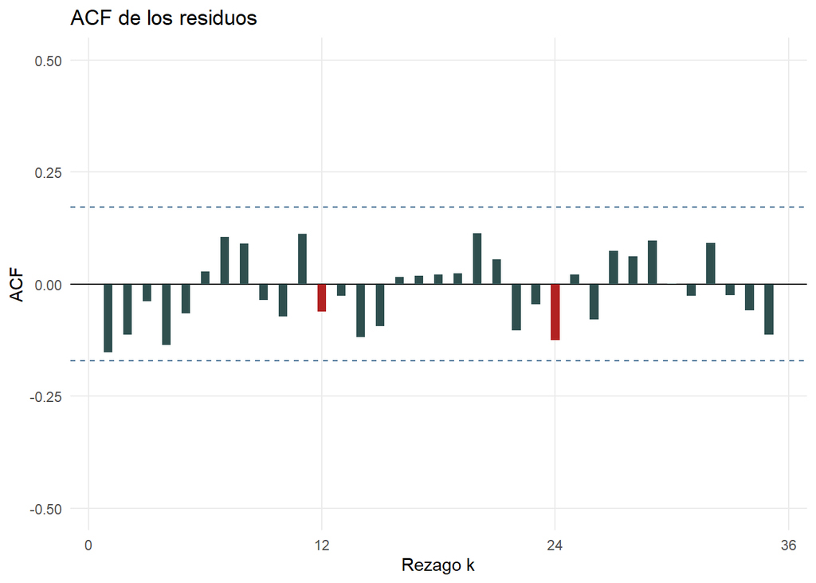

```r
supuestos$graf_acf
```

Para todos los valores de $K$ no se rechaza $H_0$ en la prueba de Ljung-Box, por lo que, con un nivel de significancia del 5%, hay evidencia muestral suficiente para sugerir que no hay autocorrelación significativa en los residuos hasta el rezago $K$ (para los 3 $K$), por lo que el modelo logra captar bien la estructura temporal. Esto también se concluye con la ACF de los residuos, donde ningún rezago supera la banda de significancia.

```r
supuestos$coeficientes
```

Parámetros estimados (ML)

| Parametro | Estimacion | EE | t_stat |
| --- | --- | --- | --- |
| ar1 | -0.2940 | 0.0875 | -3.36 |
| sar1 | 0.9782 | 0.0531 | 18.41 |
| sma1 | 0.8381 | 0.2084 | 4.02 |

Todos los coeficientes superan el umbral $\vert{}t\vert{} > 2$ (`ar1` con $t = -3,36$, `sar1` con $t = 18,41$ y `sma1` con $t = 4,02$), por lo que individualmente aportan información al ajuste.

El parámetro autorregresivo vale $\hat{\phi}_1 = -0,2940$, ubicándose claramente dentro de la región de estacionariedad ($\vert{}\hat{\phi}_1\vert{} < 1$). El coeficiente autorregresivo estacional vale $\hat{\Phi}_1 = 0,9782$ (muy cercano a 1). Esto indica que el polinomio $(1 - 0,9782 B^{12})$ está imitando un operador de diferencia estacional $\nabla_{12} = (1 - B^{12})$. Al mismo tiempo, el parámetro de media móvil estacional es muy alto ($\hat{\Theta}_1 = 0,8381$). Cuando en un modelo estacional mixto $(1,0,1)_{12}$ tanto $\hat{\Phi}_1$ como $\hat{\Theta}_1$ son muy cercanos a $1$, ambos factores tienden a cancelarse entre sí ($\frac{1 - 0,8381 B^{12}}{1 - 0,9782 B^{12}}$).

```r
supuestos$normalidad
```

Diagnóstico de normalidad

| n_residuos | Asimetria | Curtosis | JB | Valor_p |
| --- | --- | --- | --- | --- |
| 130 | -0.338 | 3.267 | 3.08 | 0.214 |

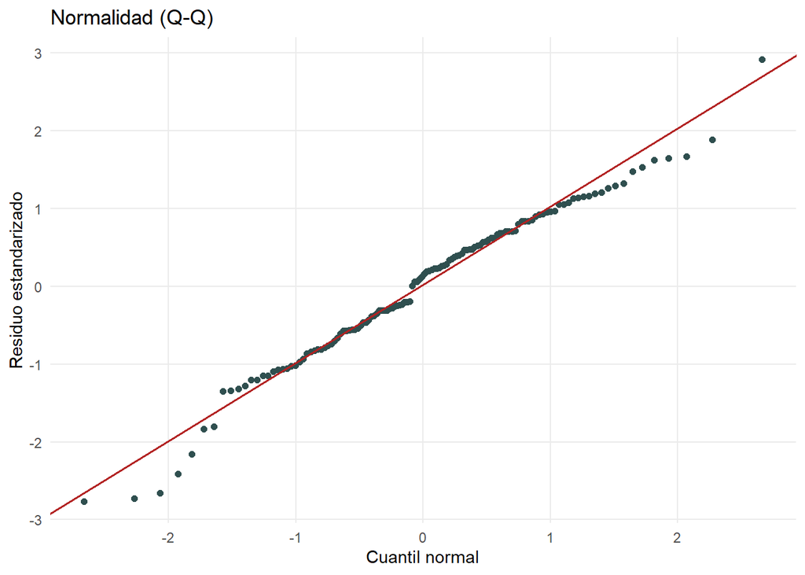

```r
supuestos$graf_qq
```

La prueba de Jarque-Bera tiene un valor p > 0.05, por lo que con un nivel de significancia del 5%, no se rechaza $H_0$, así se acepta normalidad en los residuos. Esto también se ve en la asímetria (muy cercana a 0) y en la curtosis (aproximadamente 3). El QQ-plot tiene la mayoría de puntos pegados de la línea teórica, a excepción de algunos puntos en los extremos, aunque estos representan una porción considerablemente pequeña en comparación al número total de residuos, por lo que se acepta normalidad de forma visual también.

```r
supuestos$sobreajuste
```

Pruebas de sobreajuste

| Sobreajuste | Parametro | Estimacion | t_stat |
| --- | --- | --- | --- |
| SARIMA(2,1,0)(1,0,1)_12 | ar2 | -0.1236 | -1.40 |
| SARIMA(1,1,1)(1,0,1)_12 | ma1 | 1.0000 | 105.09 |
| SARIMA(1,1,0)(2,0,1)_12 | sar2 | -0.1979 | -2.02 |
| SARIMA(1,1,0)(1,0,2)_12 | sma2 | 0.1864 | 2.03 |

Agregar un segundo término autorregresivo (`ar2` en $\text{SARIMA}(2,1,0)(1,0,1)_{12}$) resulta estadísticamente no significativo ($\hat{\phi}_2 = -0,1236$, $t = -1,40$, $\vert{}t\vert{} \le 2$), por lo que el orden $p = 1$ es suficiente.

Agregar un término de media móvil (`ma1` en $\text{SARIMA}(1,1,1)(1,0,1)_{12}$) hace que no se cumple invertibilidad ($\hat{\theta_1}=1$). Un parámetro MA con $\vert{}\hat{\theta}\vert{} \ge 0,99$ evidencia sobre-diferenciación y cancelación con el operador $\nabla$, invalidando este modelo.

Tanto al incorporar `sar2` ($\text{SARIMA}(1,1,0)(2,0,1)_{12}$, $\hat{\Phi}_2 = -0,1979$, $t = -2,02$) como al incorporar `sma2` ($\text{SARIMA}(1,1,0)(1,0,2)_{12}$, $\hat{\Theta}_2 = 0,1864$, $t = 2,03$), los estadísticos quedan apenas en el borde del umbral crítico ($\vert{}t\vert{} \approx 2$).

Este comportamiento no responde a una verdadera estructura estacional de orden 2, sino a una consecuencia directa de la **casi raíz unitaria estacional** ($\hat{\Phi}_1 = 0,9782$) y la **casi cancelación de factores** ($\hat{\Phi}_1 \approx \hat{\Theta}_1$) detectadas en el modelo base, que vuelven inestable la estimación al añadir más parámetros en $B^{12}$.

Las pruebas de sobreajuste confirman que el reloj regular no requiere mayor complejidad, pero que la parte estacional $(1,0,1)_{12}$ presenta redundancia y proximidad a una raíz unitaria estacional. En lugar de escalar a modelos de orden estacional 2, el diagnóstico indica que se debe reemplazar $(1,0,1)_{12}$ por una estructura estacional más parsimoniosa: ya sea introduciendo la diferencia estacional ($D = 1$) mediante $\text{SARIMA}(1,1,0)(0,1,1)_{12}$ (o $(0,1,1)(0,1,1)_{12}$) para absorber la raíz unitaria en $B^{12}$, o manteniendo $D = 0$ con un único factor estacional simple ($\text{SARIMA}(1,1,0)(1,0,0)_{12}$ o $(1,1,0)(0,0,1)_{12}$.

## Referencias bibliográficas

Chen, X., y P. Moraga. 2025. «Assessing dengue forecasting methods: a comparative study of statistical models and machine learning techniques in Rio de Janeiro, Brazil». *Tropical Medicine and Health* 53: 52. https://doi.org/10.1186/s41182-025-00723-7.

Diebold, Francis X., y Roberto S. Mariano. 1995. «Comparing predictive accuracy». *Journal of Business & Economic Statistics* 13 (3): 253-63. https://www.nber.org/papers/w4961.

Eastin, M. D., E. Delmelle, I. Casas, J. Wexler, y C. Self. 2014. «Intra- and interseasonal autoregressive prediction of dengue outbreaks using local weather and regional climate for a tropical environment in Colombia». *The American Journal of Tropical Medicine and Hygiene* 91 (3): 598-610. https://doi.org/10.4269/ajtmh.13-0303.

Gharbi, M., P. Quenel, J. Gustave, et al. 2011. «Time series analysis of dengue incidence in Guadeloupe, French West Indies: Forecasting models using climate variables as predictors». *BMC Infectious Diseases* 11: 166. https://doi.org/10.1186/1471-2334-11-166.

Hasan, Pratyay, Tazdin Delwar Khan, Ismail Alam, y Md. Emdadul Haque. 2024. «Dengue in Tomorrow: Predictive Insights From ARIMA and SARIMA Models in Bangladesh: A Time Series Analysis». *Health Science Reports* 7 (12): e70276. https://doi.org/10.1002/hsr2.70276.

Hyndman, Rob J., y George Athanasopoulos. 2021. *Forecasting: principles and practice*. 3.ª ed. OTexts. https://otexts.com/fpp3/.

Hyndman, Rob J., y Yeasmin Khandakar. 2008. «Automatic time series forecasting: the forecast package for R». *Journal of Statistical Software* 27 (3): 1-22. https://doi.org/10.18637/jss.v027.i03.

Hyndman, Rob J., y Anne B. Koehler. 2006. «Another look at measures of forecast accuracy». *International Journal of Forecasting* 22 (4): 679-88. https://robjhyndman.com/papers/mase.pdf.

Instituto Nacional de Salud. 2026. *Búsqueda de microdatos: Casos de dengue 2015-2025*. Portal Sivigila web 4.0. https://portalsivigila.ins.gov.co/Paginas/Buscador.aspx.

López-Montenegro, Luis Eduardo, Ana María Pulecio-Montoya, y Germán Arturo Marcillo-Hernández. 2019. «Dengue Cases in Colombia: Mathematical Forecasts for 2018–2022». *MEDICC Review* 21 (2-3): 38-45. https://www.scielosp.org/article/medicc/2019.v21n2-3/38-45/#.

Martinez, E. Z., E. A. S. da Silva, y A. L. D. Fabbro. 2011. «A SARIMA forecasting model to predict the number of cases of dengue in Campinas, State of São Paulo, Brazil». *Revista da Sociedade Brasileira de Medicina Tropical* 44 (4): 436-40. https://doi.org/10.1590/S0037-86822011000400007.

Navarro Valencia, V., Y. Dı́az, J. M. Pascale, M. F. Boni, y J. E. Sanchez-Galan. 2021. «Assessing the Effect of Climate Variables on the Incidence of Dengue Cases in the Metropolitan Region of Panama City». *International Journal of Environmental Research and Public Health* 18 (22): 12108. https://doi.org/10.3390/ijerph182212108.

Riley, P., M. Ben-Nun, J. Turtle, D. Bacon, y S. Riley. 2020. «SARIMA Forecasts of Dengue Incidence in Brazil, Mexico, Singapore, Sri Lanka, and Thailand: Model Performance and the Significance of Reporting Delays». *medRxiv*, advance online publication. https://doi.org/10.1101/2020.06.26.20141093.

Shumway, Robert H., y David S. Stoffer. 2017. *Time Series Analysis and Its Applications: With R Examples*. 4.ª ed. Springer. https://www.stat.pitt.edu/stoffer/tsa4/.

Vélez, Jorge I., Juan C. Correa, y Fernando Marmolejo-Ramos. 2015. «A new approach to the Box-Cox transformation». *Frontiers in Applied Mathematics and Statistics* 1: 12. https://doi.org/10.3390/fams.2015.00012.

Zhao, N., K. Charland, M. Carabali, E. O. Nsoesie, M. Maheu-Giroux, et al. 2020. «Machine learning and dengue forecasting: Comparing random forests and artificial neural networks for predicting dengue burden at national and sub-national scales in Colombia». *PLOS Neglected Tropical Diseases* 14 (9): e0008056. https://doi.org/10.1371/journal.pntd.0008056.